# Import Raster Data

This Notebook will demonstrate how to import raster GIS data into R.

## Import a Landsat 8 Image

Because Landsat images are multi-band we import them using the `brick()`:

```r
library(raster)
yose_l8_rst <- raster::brick("./data/yose_l8_20180822_b2345.tif")
yose_l8_rst
```

```
class      : RasterBrick
dimensions : 2555, 2014, 5145770, 4  (nrow, ncol, ncell, nlayers)
resolution : 30, 30  (x, y)
extent     : 246315, 306735, 4152885, 4229535  (xmin, xmax, ymin, ymax)
crs        : +proj=utm +zone=11 +datum=WGS84 +units=m +no_defs
source     : yose_l8_20180822_b2345.tif
names      : yose_l8_20180822_b2345.1, yose_l8_20180822_b2345.2, yose_l8_20180822_b2345.3, yose_l8_20180822_b2345.4
min values :                     7208,                     6100,                     5357,                     4330
max values :                    29840,                    30960,                    32595,                    30481
```

View a summary of the bands:

```r
summary(yose_l8_rst)
```

```
        yose_l8_20180822_b2345.1 yose_l8_20180822_b2345.2 yose_l8_20180822_b2345.3
Min.                        7411                     6366                     5609
1st Qu.                     8589                     8072                     7749
Median                      9254                     8908                     8965
3rd Qu.                    10419                    10456                    10960
Max.                       26650                    27824                    29578
NA's                           0                        0                        0
        yose_l8_20180822_b2345.4
Min.                        4933
1st Qu.                    12439
Median                     13980
3rd Qu.                    15809
Max.                       27484
NA's                           0
```

We can tell from the values that Landsat pixel values are 16-bit (0..65536). Remind ourselves of the band combinations for Landsat 8:

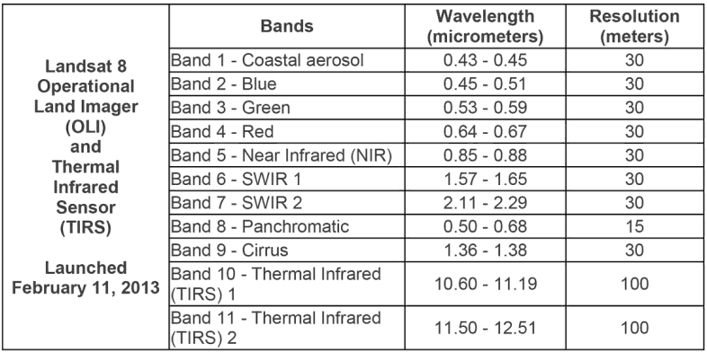

## Plot it with plotRGB

Plot a Pseudo True Color:

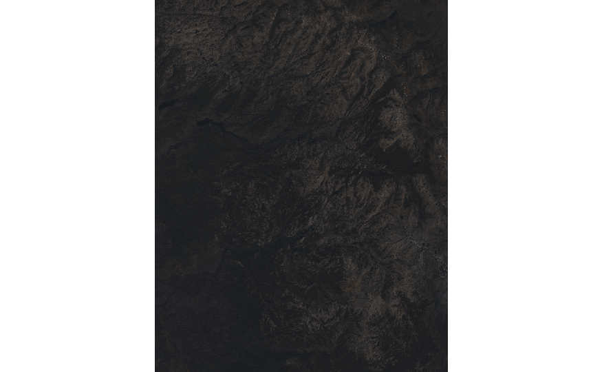

Isn’t that awful? The problem is the range of brightness values is fairly narrow. The Landsat sensor isn’t like the camera in your phone, which artificially stretches values to make them look pleasing to the eye.

To make it look better, we can pass the `stretch` argument to have it make a contrast stretch:

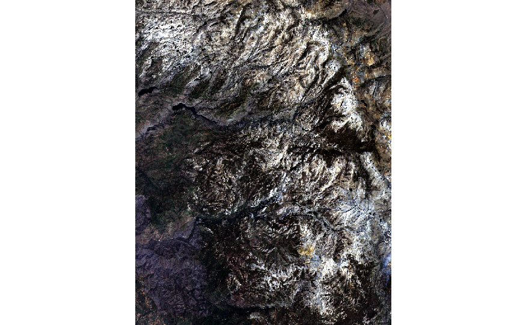

Plot a False Color Composite:

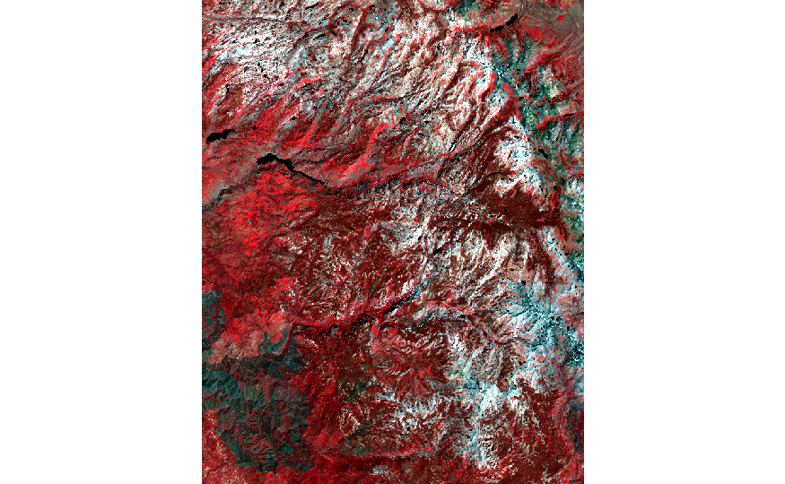

You can do a lot more with satellite imagery using [RStoolbox](https://bleutner.github.io/RStoolbox/rstbx-docu/spectralIndices.html).

## Plot it with tmap

To overlay the park boundary, we’ll use tmap:

```
stars object downsampled to 888 by 1126 cells. See tm_shape manual (argument raster.downsample)
```

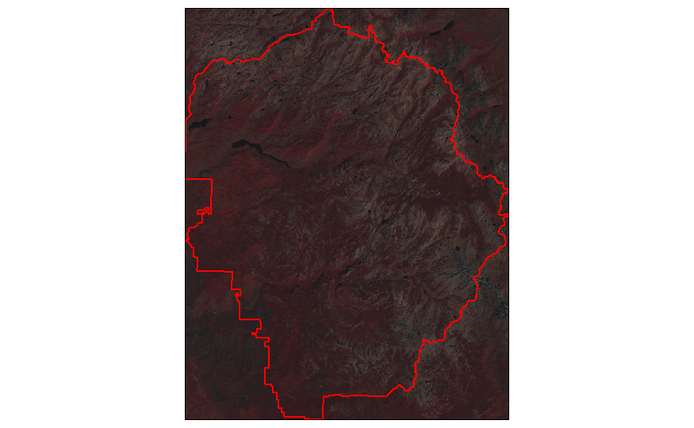

```r
library(sf)
library(tmap)
epsg_utm11n_wgs84 <- 32611
yose_bnd_utm <- sf::st_read(dsn="./data", layer="yose_boundary") %>%
  st_transform(epsg_utm11n_wgs84)
tm_shape(yose_l8_rst) +
  tm_rgb(r=4, g=3, b=2, interpolate = FALSE, max.value = 2 ^ 16) +
tm_shape(yose_bnd_utm) +
  tm_borders(col="red", lwd=2) +
tm_layout(legend.show = FALSE)
```

## End

Congratulations, you’ve completed the Notebook!

To view your Notebook at HTML, save it (again), then click the ‘Preview’ button in the RStudio toolbar.